# R Notebook

Laboratorio 1

Estadística Computacional

25 de Septiembre del 2017

Andrés Huerta Rojo 201473544-8 andres.huerta.14@sansano.usm.cl Malla Nueva

Gonzalo Duran Saez 201473507-3 gonzalo.duran.14@sansano.usm.cl Malla Nueva

```r
library(readr)
evals <- read_csv("~/Downloads/R proyectos/Evaluacion Profesores/evals.csv") #En caso de error de ejecución cambiar la dirección que aparece en esta linea por la correspondiende a la ubicación del archivo.
metadata <- read_csv("~/Downloads/R proyectos/Projecto SunRoof/metadata.csv")
evals_mujeres <- subset(evals, gender == "female")
evals_hombres <- subset(evals, gender == "male")
evals_ethn_mayoria <- subset(evals, ethnicity == "not minority")
evals_ethn_minoria <- subset(evals, ethnicity == "minority")
```

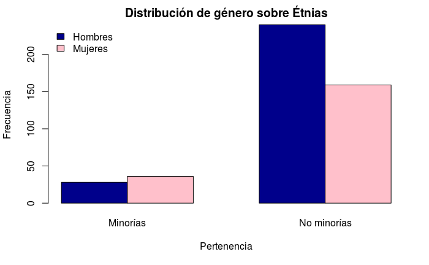

```r
d <- data.frame(row.names = c("Minorías","No minorías"), Hombres =  c(table(evals_hombres[3])),
                Mujeres = c(table(evals_mujeres[3])))
d <- do.call(rbind, d)
colnames(d) = c("Minorías","No minorías")
barplot(d, beside = TRUE, legend.text = rownames(d),
        args.legend = list(x = "topleft",  bty="n"), xlab = "Pertenencia", ylab = "Frecuencia", col = c("darkblue", "pink"), main = "Distribución de género sobre Étnias")
```

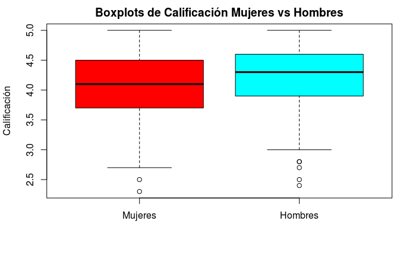

```r
boxplot(evals_mujeres$score, evals_hombres$score, names = c("Mujeres", "Hombres"), col = rainbow(2), ylab = "Calificación", main = "Boxplots de Calificación Mujeres vs Hombres")
```

A simple vista, se puede observar que los segundos y tercer cuartiles de cada género se encuentran sobre la calificación media de 3, en el caso de los hombres este se encuentra acumulado un poco más alto y concentrado que el de las mujeres. Ademas el inicio del primer cuartil de hombres esta ubicado por sobre el primer cuartil de mujeres, existen algunos elementos extremos, pero por la cantidad de valores que se muestran aparentan no ser muy significativos.

Habiendo expuesto lo anterior se podría concluir que la evaluación general es mayor para los hombres que para mujeres, lo cual implicaría que los estudiantes prefirieron los métodos de enseñanza de los hombres, pero la diferencia apreciada no es muy significativa.

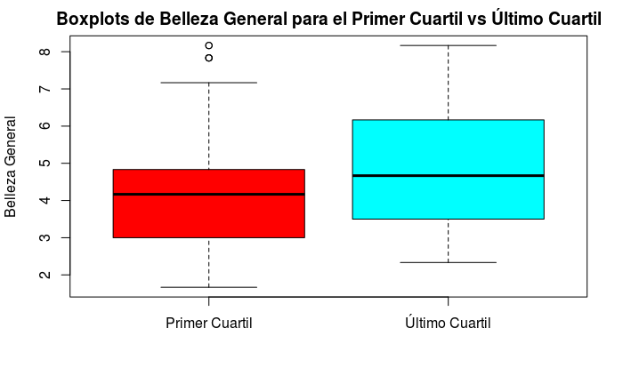

```r
#quantile(evals$score, 0.75)
cuarto_cuartil <- subset(evals, score >= quantile(evals$score, 0.75))
#quantile(evals$score, 0.25)
primer_cuartil <- subset(evals, score <= quantile(evals$score, 0.25))
boxplot(primer_cuartil$bty_avg, cuarto_cuartil$bty_avg, names = c("Primer Cuartil", "Último Cuartil"), col = rainbow(2), ylab = "Belleza General", main = "Boxplots de Belleza General para el Primer Cuartil vs Último Cuartil")
```

Aparentemente los alumnos si toman en consideración la belleza de un profesor al momento de evaluar, por la forma del boxplot se puede ver que la mediana del ultimo cuartil se encuentra un poco sobre la mediana del primer cuartil, es díficil interpretar la información sin saber si son hombres votando por profesoras, mujeres votando por profesores, o los distintos tipos de orientación que puede haber.

Existen excepciones de profesores calificados dentro del primer cuartil, pero irónicamente son casos extremos que se encuentran fuera del bigote del boxplot.

Podría encontrarse la posibilidad, que al momento de evaluar a los profesores que no fueron queridos por los alumnos (vale decir, evaluados negativamente en la variable score) también se vieran afectados en esta parte de la evaluación.

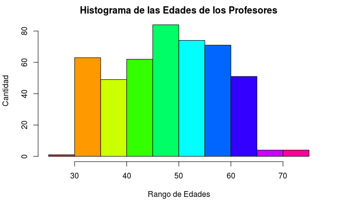

```r
hist(evals$age, right = TRUE, col = rainbow(10), main = "Histograma de las Edades de los Profesores", xlab = "Rango de Edades", ylab = "Cantidad")
```

Se puede ver que la mayoria de los profesores se encuentran en el rango entre los 45 y 50 años, pero no es una diferencia muy exagerada con sus rangos vecinos, a excepción de los extremos, donde los profesores mas jóvenes o de mayor edad parecen ser los de menor frecuencia, este último puede atribuirse a que los 65 años corresponden a la edad de jubilación promedio de estados unidos, por lo tanto no es raro ver que su frecuencia es menor.

```r
doscuatro_a_cuarenta <- subset(evals, age >= 29 & age < 40)
cuarenta_a_sesenta <- subset(evals, age >= 40 & age < 60)
sesenta_omas <- subset(evals, age >= 60)
tabla <- matrix(c(mean(doscuatro_a_cuarenta$score), var(doscuatro_a_cuarenta$score), sd(doscuatro_a_cuarenta$score), median(doscuatro_a_cuarenta$score), mean(cuarenta_a_sesenta$score), var(cuarenta_a_sesenta$score), sd(cuarenta_a_sesenta$score), median(cuarenta_a_sesenta$score), mean(sesenta_omas$score), var(sesenta_omas$score), sd(sesenta_omas$score), median(sesenta_omas$score)), ncol = 4, byrow = TRUE)
colnames(tabla) <- c("Media", "Varianza", "Des_Estandar", "Mediana")
rownames(tabla) <- c("29 - 39", "40 - 59", "60 o mas")
tabla <- as.table(tabla)
tabla
```

```
             Media  Varianza Des_Estandar   Mediana
29 - 39  4.2447619 0.2511502    0.5011489 4.4000000
40 - 59  4.1782918 0.2782771    0.5275197 4.2000000
60 o mas 4.0662338 0.4104238    0.6406433 4.3000000
```

Primero que todo, se debe tener en cuenta que el grupo de profesores entre 40 y 59 años, es el que tiene la mayor cantidad de personas entre los 3 grupos (se puede desprender del histograma de la parte anterior).

Por la media, se puede ver que la diferencia de edad no es un factor muy importante al momento de evaluar a los profesores, la mayor diferencia entre los tres rangos de edades es de aproximadamente 0.2 puntos.

De la varianza se observa como el valor aumenta a mayor edad tengan los profesores, siendo su mayor exponente sobre los profesores sobre 60 años, así mismo ocurre con la dsviación estandar, dispersando más los datos a mayor edad del profesor respectivo.

La mediana en un rango similar entre ellas.

10. Al parecer, la experiencia no determina la calidad del profesor (por lo menos en la Universidad de Texas), esto debido a que la media para la calificación de cada grupo de edad observada en el item h) no son muy distantes unas de otras.

La evaluación de la belleza de un profesor se puede ver afectada por la evaluación general, o analogamente la belleza puede influir en la nota final de cada profesor.

```r
sunroof <- read_csv("~/Downloads/R proyectos/Projecto SunRoof/sunroof.csv")
```

```r
x2 <- aggregate(sunroof$existing_installs_count, by=list(sunroof$state_name), FUN=sum)
x2 <- x2[order(-x2$x), ][1:5, ]
x2
```

|  | Group.1 | x |
| --- | --- | --- |
| 5 | California | 328900 |
| 10 | Florida | 104152 |
| 3 | Arizona | 39560 |
| 12 | Hawaii | 25413 |
| 6 | Colorado | 24270 |

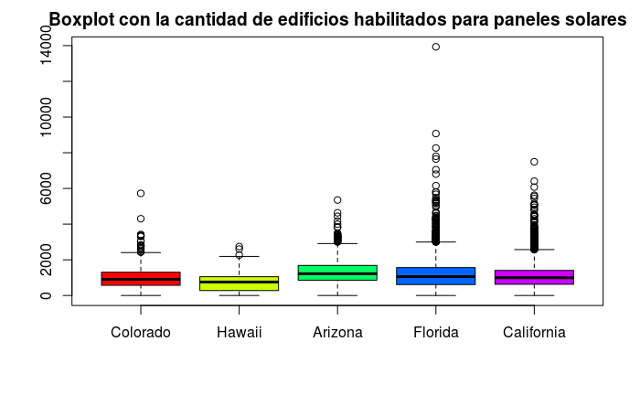

```r
s_colorado <- subset(sunroof, state_name == "Colorado")
s_hawaii <- subset(sunroof, state_name == "Hawaii")
s_arizona <- subset(sunroof, state_name == "Arizona")
s_florida <- subset(sunroof, state_name == "Florida")
s_california <- subset(sunroof, state_name == "California")
boxplot(s_colorado$count_qualified, s_hawaii$count_qualified, s_arizona$count_qualified, s_florida$count_qualified, s_california$count_qualified, main = "Boxplot con la cantidad de edificios habilitados para paneles solares", names = c("Colorado", "Hawaii", "Arizona", "Florida", "California"), col = rainbow(5))
```

```r
medias <- c(mean(s_colorado$number_of_panels_median, na.rm = TRUE), mean(s_hawaii$number_of_panels_median, na.rm = TRUE), mean(s_arizona$number_of_panels_median, na.rm = TRUE), mean(s_florida$number_of_panels_median, na.rm = TRUE), mean(s_california$number_of_panels_median, na.rm = TRUE))
medias
```

```
[1] 32.89524 71.39286 50.55778 59.02594 42.83634
```

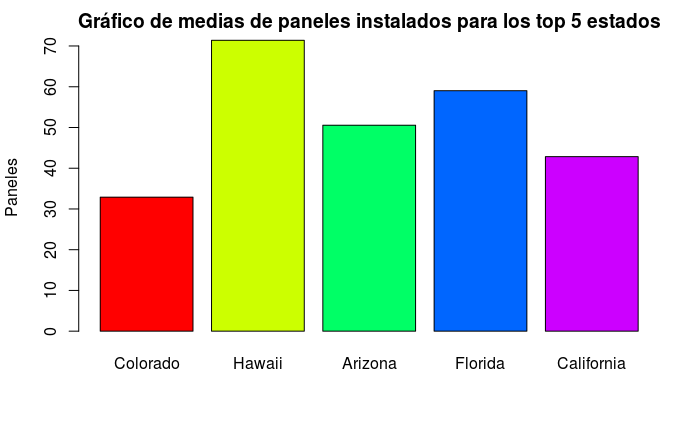

```r
barplot(medias, main = "Gráfico de medias de paneles instalados para los top 5 estados", col = rainbow(5), names = c("Colorado", "Hawaii", "Arizona", "Florida", "California"), ylab = "Paneles")
```

5. Analizando el gráfico con las medias de edificios instalados por región y los boxplots con edificios habilitados para paneles solares se puede concluir que Hawaii podría ser el estado con mayor cantidad de paneles solares instalados por edificios (razón de paneles solares por edificio). Tomando encuenta que es un gran sector turistico en estados unidos, probablemente prefieren mantener un ambiente mas ameno que se podría ver afectado por otro tipo de generación de energía.

Por la forma de los boxplots de los estados que superan en cantidad a Hawaii se podría deducir que poseen muchos mas edificios, pero con una menor cantidad de paneles solares instalados. California a pesar de ser el estado con mayor cantidad de paneles es (entre los top 5) el segundo estado con menor cantidad de paneles solares por región.

```r
is.inside = 0
esfera <- list()
dimensiones = 3 #dimensiones
radio = 1 # Radio
n = 10000 #Puntos para aproximar, si se agranda este numero el tiempo de ejecución aumenta mucho, lo maximo que se logro fue 100000, pero tuvo un alto tiempo de ejecución para solamente 2 dimensiones.
for(i in 1:n){
  esfera[[i]] <- runif(dimensiones, -radio, radio)
}
for(i in 1:n){
  sum = 0
  for(j in 1:dimensiones){
    sum = sum + esfera[[i]][[j]]^2
  }
  if(sum <= radio^2){
    is.inside = is.inside + 1
  }
}
multiplicador = dimensiones*2^(dimensiones-1)*gamma(dimensiones/2)
pi.estimate = (is.inside / n*multiplicador)^(2/dimensiones)
pi.estimate
```

```
[1] 3.152388
```

```r
volumen <- (pi.estimate^(dimensiones/2))*(radio^dimensiones) / gamma((dimensiones/2) +1) #Por mucho que se intento no se pudo calcular el área de una esfera n dimensional, lo mas cercano que se consiguio fue de este pdf http://scipp.ucsc.edu/~haber/ph116A/volume_11.pdf pero no daba.
volumen
```

```
[1] 4.2104
```

```r
simulaciones = 10000
total_muertes = 0
for(i in 1:simulaciones){
  vidas_A = 4
  for(j in 1:8){
    if(sample(0:1, 1) == 0){
      vidas_A = vidas_A - 1
      if(vidas_A == 0){
        total_muertes = total_muertes + 1
        break
      }
    }
  }
}
total_muertes/simulaciones
```

```
[1] 0.6311
```